# Avaliação Continuada - Aula 7

**Execute a célula a seguir para imp ortar as bibliotecas de que vamos precisar e criar a variável `titanic` com nossa base de dados.**

```python
# Importando a biblioteca seaborn
import seaborn as sns
import matplotlib.pyplot as plt

# Carregando a base de dados 'titanic'
titanic = sns.load_dataset("titanic")

titanic.head()
```

|  | survived | pclass | sex | age | sibsp | parch | fare | embarked | class | who | adult_male | deck | embark_town | alive | alone |
| --- | --- | --- | --- | --- | --- | --- | --- | --- | --- | --- | --- | --- | --- | --- | --- |
| 0 | 0 | 3 | male | 22.0 | 1 | 0 | 7.2500 | S | Third | man | True | NaN | Southampton | no | False |
| 1 | 1 | 1 | female | 38.0 | 1 | 0 | 71.2833 | C | First | woman | False | C | Cherbourg | yes | False |
| 2 | 1 | 3 | female | 26.0 | 0 | 0 | 7.9250 | S | Third | woman | False | NaN | Southampton | yes | True |
| 3 | 1 | 1 | female | 35.0 | 1 | 0 | 53.1000 | S | First | woman | False | C | Southampton | yes | False |
| 4 | 0 | 3 | male | 35.0 | 0 | 0 | 8.0500 | S | Third | man | True | NaN | Southampton | no | True |

### Sobre os dados

No exercício de hoje, vamos praticar a customização de gráficos. Vamos partir das seguintes variáveis:

- `fare`: indica o valor pago pela passagem, em dólares ($).
- `survived`: indica se o passageiro sobreviveu (`"1"`) ou não sobreviveu (`"0"`) ao afundamento do Titanic.
- `class`: indica a classe da passagem comprada pelo passageiro.

Vamos continuar trabalhando quase de onde paramos no exercício anterior, buscando a melhor forma de representar o que encontramos.

Você começará trabalhando do gráfico abaixo:

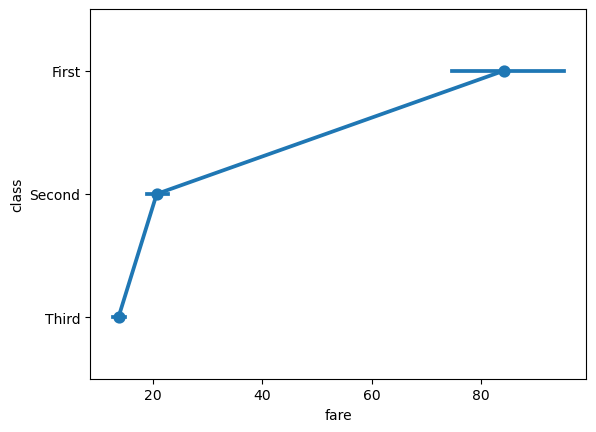

```python
# Escreva sua resposta abaixo
sns.pointplot(
    x="fare",
    y="class",
    data=titanic,
)
```

# Exercício de hoje - Parte 1

Você deve alterar o gráfico anterior para mudar três aspectos:

1. Remover a linha que liga os pontos. Você pode fazer isso passando uma string vazia para o argumento `linestyle` da função.
2. Adicionar o indicador ao fim da barra de erro. Você pode fazer isso com o argumento `capsize`. Uma sugestão é usar o valor `0.15`
3. Alterar a barra de erro para que ela exiba o percentil com os 50% centrais dos dados

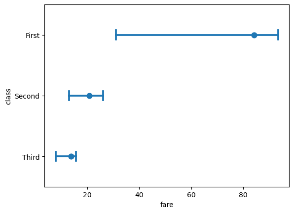

```python
# gabarito

sns.pointplot(
    x="fare",
    y="class",
    data=titanic,
    linestyle="",
    capsize=0.15,
    errorbar=["pi", 50]
)
```

### Exercício de hoje - Parte 2

Agora você deve customizar outro gráfico:

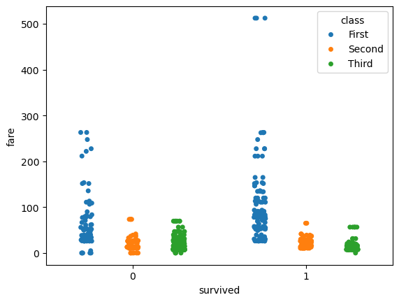

```python
sns.stripplot(
    y="fare",
    x="survived",
    hue="class",
    data=titanic,
    dodge=True, # esse argumento faz com que as categories do hue não fiquem sobrepostas
)
```

Adicione título e rótulos nos eixos, e defina também uma paleta de cores diferente da padrão. Você pode criar a paleta escolhendo cada uma das cores ([veja a lista de cores](https://matplotlib.org/stable/gallery/color/named_colors.html)) ou escolher uma paleta de cores pré-definida.

Veja algumas das paletas que você pode escolher pelo nome:

[figure not shown]

Altere a paleta com o argumento `palette` e defina título e rótulos apropriados para os eixos X e Y.

Se preferir, você pode criar um dicionário para definir sua paleta preenchendo a variável `minha_paleta`.

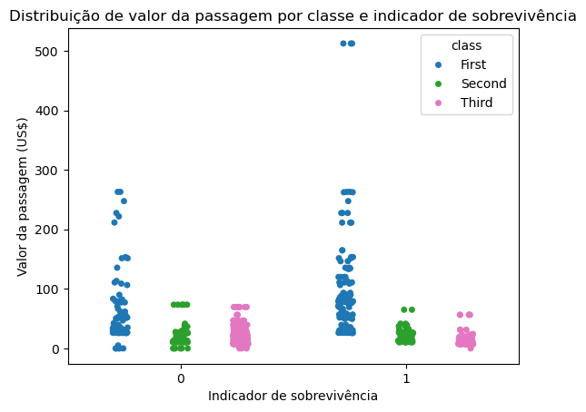

```python
# gabarito
minha_paleta = {
    "First": "tab:blue",
    "Second": "tab:green",
    "Third": "tab:pink"
}

fig, ax = plt.subplots()

sns.stripplot(
    y="fare",
    x="survived",
    hue="class",
    data=titanic,
    dodge=True,
    palette=minha_paleta,
    ax=ax,
)

ax.set_title("Distribuição de valor da passagem por classe e indicador de sobrevivência")
ax.set_ylabel("Valor da passagem (US$)")
ax.set_xlabel("Indicador de sobrevivência")
```

```python
minha_paleta = {}

fig, ax = plt.subplots()

sns.stripplot(
    y="fare",
    x="survived",
    hue="class",
    data=titanic,
    dodge=True,
    ax=ax,
)
```